# Persistent Kinase and Chromatin Memory in LPS-Tolerized Human Monocytes

Integrated RNA-seq and ChIP-seq re-analysis of GSE85246

# 1 Executive Summary

This report presents a downstream computational re-analysis of the human monocyte innate-memory dataset **GSE85246/GSE85245**, integrating RNA-seq state, β-glucan rescue/restimulation behavior, and chromatin information.

The RNA analysis identified 24 Day-6 kinase-family candidates and assigned integrated trajectory priorities using acute response, persistent Day-6 state, β-glucan rescue, and restimulation information.

The original Step-07/07b/08 chromatin workflow used directional H3K27ac/H3K4me1 evidence and produced MAP3K8, BMPR1A, and JAK3 as the strongest exploratory integrated candidates. A subsequent formal promoter audit showed that this earlier ranking should **not** be treated as the final promoter-level statistical result.

The corrected audit uses TSS ±2 kb promoter windows, mean BigWig signal, log transformation, an unpaired limma design, and kinase-restricted statistical testing. Three RPMI Day-6 replicate-2 tracks labelled `NotNormalized` were explicitly audited and rescaled locally.

The local reconstruction did **not** reproduce every numerical FDR from the independent corrected analysis. Therefore, local statistics and independently reported corrected promoter results are kept separate.

The current downstream priority produced by the integration workflow is:

**JAK3, EPHB2**

**JAK3** is supported by the project’s RNA analysis and by independently corrected H3K27ac/H3K4me3 promoter evidence. **EPHB2** is a washout-emergent RNA candidate with independently corrected H3K27ac promoter support.

MET, MAP3K8, and BMPR1A remain RNA-supported candidates but are not currently classified as formally promoter-chromatin-supported.

> The exact corrected Tobias FDR values are treated as independent benchmark results and are not claimed as locally reproduced statistics.

# 2 1. Biological Question

The biological question was whether transient LPS exposure leaves a persistent kinase-associated molecular state after washout, whether β-glucan treatment can reverse or remodel that state, and whether persistent transcriptional changes are accompanied by persistent regulatory chromatin changes.

The analysis therefore followed the sequence:

**acute response → post-washout memory → kinase prioritization → rescue/restimulation → integrated RNA trajectory → chromatin persistence → final RNA/chromatin integration**

This ordering was chosen to distinguish initial LPS responsiveness from the later persistent memory state.

# 3 2. Dataset and Experimental Structure

The project analyzes data from **GSE85246**, including RNA-seq and ChIP-seq components associated with LPS tolerance and β-glucan-mediated reprogramming in primary human monocytes/macrophages.

The main analytical comparisons were:

- **Day 1:** LPS versus RPMI, representing the initial response.
- **Day 6:** LPS-history versus RPMI-history after washout, representing the persistent state.
- **Restimulation:** comparison of restimulation responses between LPS-history and RPMI-history cells.
- **β-glucan rescue:** directional assessment of whether rescue moved expression or chromatin signal back toward the RPMI state.
- **Chromatin:** H3K27ac, H3K4me1, and H3K4me3. The earlier exploratory workflow evaluated H3K27ac/H3K4me1 promoter and non-promoter patterns; the corrected formal promoter audit prioritizes H3K27ac and H3K4me3 at TSS ±2 kb.

# 4 3. Analytical Workflow

The project now contains two linked workflows.

The original RNA and exploratory chromatin workflow is:

```
01_setup_and_data.R
        ↓
02_initial_LPS_response.R
        ↓
03_persistent_kinase_memory.R
        ↓
04_BG_rescue_and_restimulation.R
        ↓
05_integrated_kinase_trajectory.R
        ↓
06_make_final_kinase_figure.R
        ↓
07_epigenetic_persistence.R
        ↓
07b_unbiased_distal_chromatin.R
        ↓
08_make_final_chromatin_figures.R
```

This historical workflow can be rerun with:

```bash
Rscript --vanilla run_all.R
```

The corrected Day-6 promoter audit is run separately because it requires local GEO BigWig files that are intentionally excluded from Git:

```
12a file audit
    ↓
12c BigWig global QC
    ↓
12d TSS ±2 kb promoter quantification
    ↓
12e RPMI_d6_rep2 normalization correction
    ↓
12j local kinase-restricted unpaired limma
    ↓
12m transparent final integration
```

Run the corrected audit with:

```bash
Rscript --vanilla run_corrected_chromatin_audit.R
```

The final integration explicitly distinguishes locally reproduced chromatin statistics from the independently corrected promoter results.

# 5 4. Day-1 Initial LPS Response

Day-1 LPS-versus-RPMI analysis was used to characterize the acute response rather than define the final memory-kinase candidate set.

Because only two matched Day-1 pairs were available, the acute analysis had limited multiple-testing power. Day-1 effects were therefore used later as supporting trajectory information rather than as a mandatory filter for memory-candidate selection.

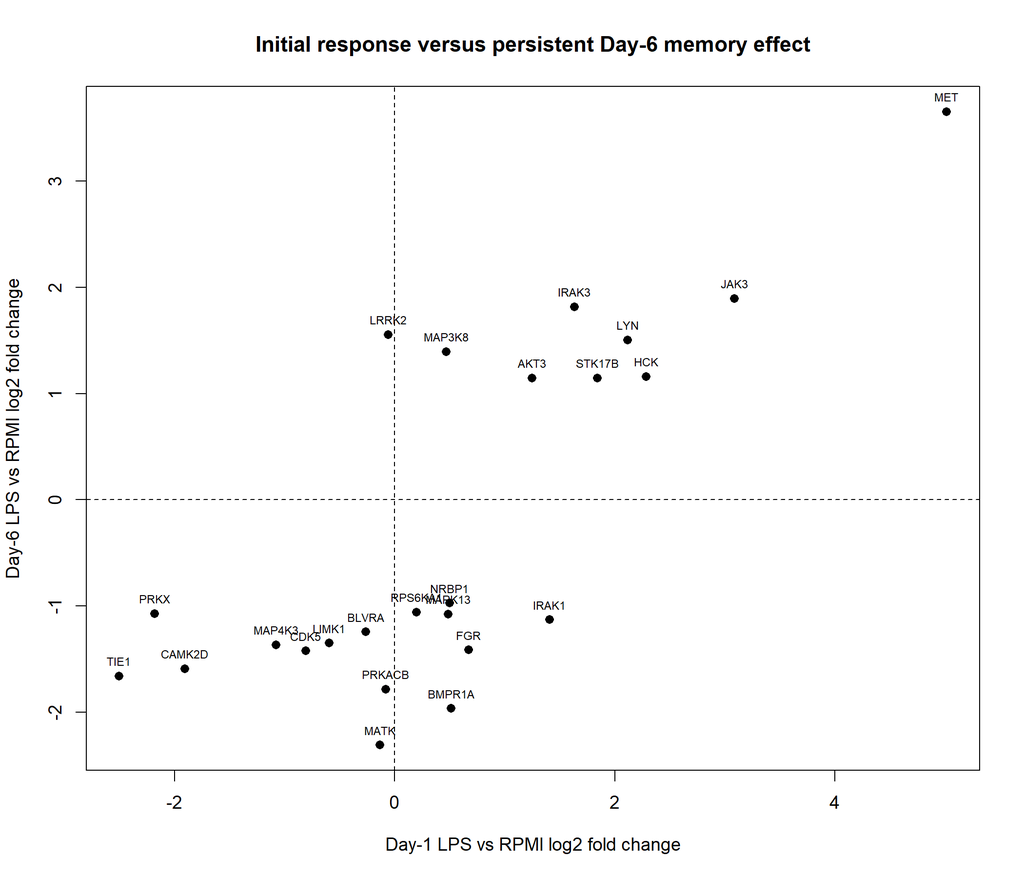

This design allows a kinase to be retained as a genuine Day-6 memory candidate even when its Day-1 signal is weak, thereby avoiding the assumption that every persistent state must first show a strong acute transcriptional response.

# 6 5. Day-6 Persistent Kinase Memory

The primary kinase-memory set was defined directly from the Day-6 LPS-history versus RPMI-history comparison using the predefined canonical kinase family.

The final Day-6 memory set contained **24 kinases**.

Day-6 memory-associated kinase candidates

| SYMBOL | P.Value |
| --- | --- |
| IRAK3 | 0.0000134 |
| MAP4K3 | 0.0000459 |
| CAMK2D | 0.0000840 |
| MET | 0.0001252 |
| PRKX | 0.0004220 |
| AKT3 | 0.0004561 |
| HCK | 0.0004567 |
| LRRK2 | 0.0005050 |
| IRAK1 | 0.0005936 |
| FGR | 0.0006066 |
| MAP3K8 | 0.0006439 |
| PRKACB | 0.0006836 |
| RPS6KA1 | 0.0006927 |
| NRBP1 | 0.0010288 |
| MATK | 0.0010583 |
| LYN | 0.0011571 |
| LIMK1 | 0.0011607 |
| BLVRA | 0.0016168 |
| BMPR1A | 0.0016386 |
| CDK5 | 0.0019194 |
| STK17B | 0.0019580 |
| TIE1 | 0.0020657 |
| MAPK13 | 0.0022749 |
| JAK3 | 0.0022765 |

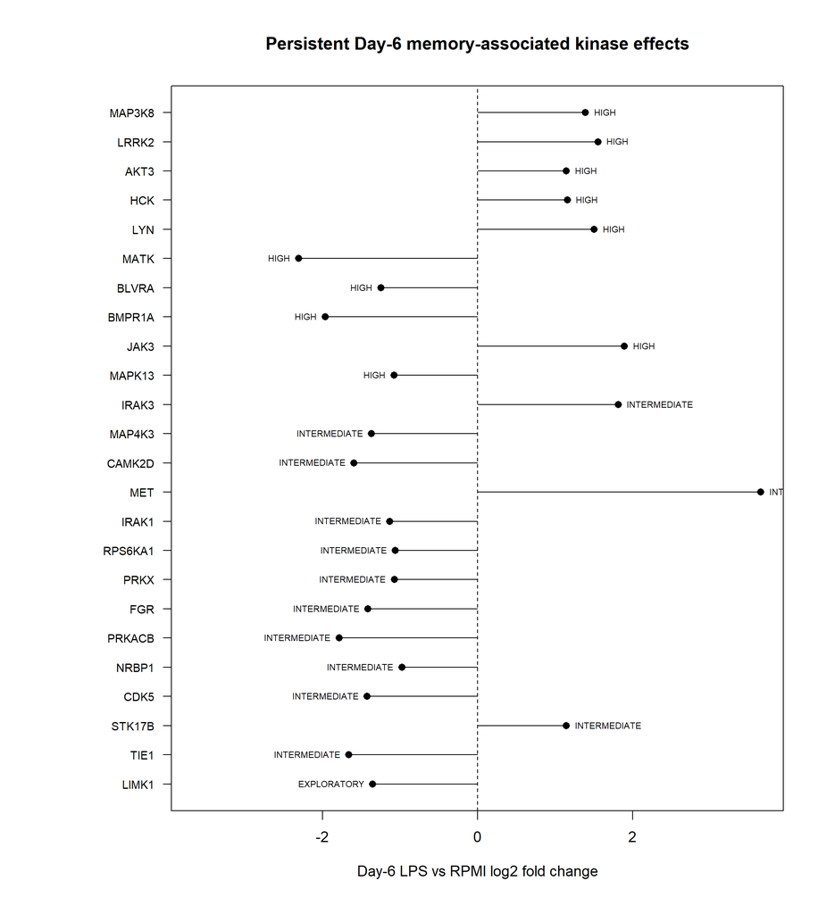

The candidate-family FDR is interpreted conditionally within the predefined kinase family, while genome-wide evidence is retained separately for transparency.

# 7 6. β-Glucan Rescue and Restimulation

Restimulation analysis tested whether the response to a new LPS challenge differed according to previous LPS exposure.

The formal matched response model compared:

$$(LPS_{restim} - LPS_{baseline}) -
(RPMI_{restim} - RPMI_{baseline})$$

No memory kinase reached genome-wide significance for the history-by-restimulation interaction after multiple-testing correction. Consequently, interaction results were not treated as independent statistical confirmation.

Instead, rescue/restimulation evidence was integrated directionally:

- whether β-glucan baseline expression moved toward RPMI;
- whether the restimulation response was blunted or altered;
- whether β-glucan rescue moved the restimulation response toward the naive/RPMI-like response.

Because the rescue arm had only two samples, rescue conclusions are descriptive and directional.

# 8 7. Integrated RNA Trajectory

The RNA-level integration retained all 24 formal Day-6 memory kinases while assigning an evidence-based follow-up priority.

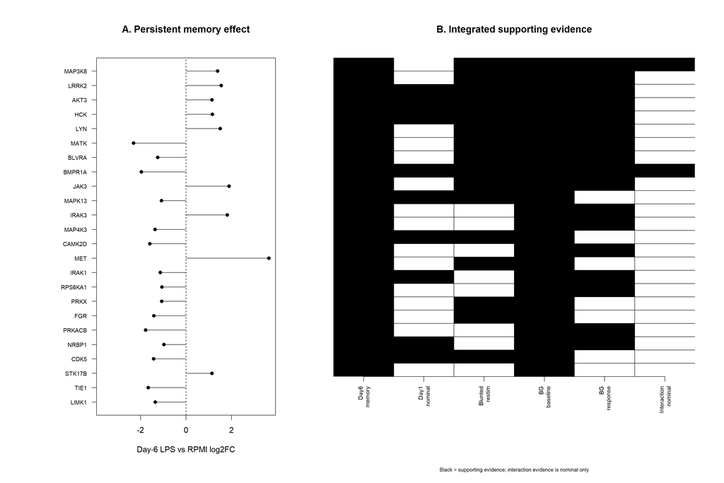

The HIGH-priority RNA set contained **10 kinases**:

MAP3K8, JAK3, LYN, LRRK2, BLVRA, AKT3, HCK, MATK, MAPK13, BMPR1A

Priority is an integrated directional-evidence label and **not a new significance test**.

# 9 8. Legacy Exploratory Chromatin Analysis

Steps 07, 07b, and 08 are retained as analysis provenance.

The earlier chromatin workflow evaluated directional H3K27ac and H3K4me1 patterns at promoter and condition-blind selected non-promoter regions. Step 07b corrected the original post-hoc distal-window selection problem by selecting one non-promoter region per gene without using condition-specific direction.

That exploratory workflow produced MAP3K8, BMPR1A, and JAK3 as the highest integrated candidates. These outputs remain useful for historical and locus-level exploration, but they no longer define the final formal promoter-supported candidate hierarchy.

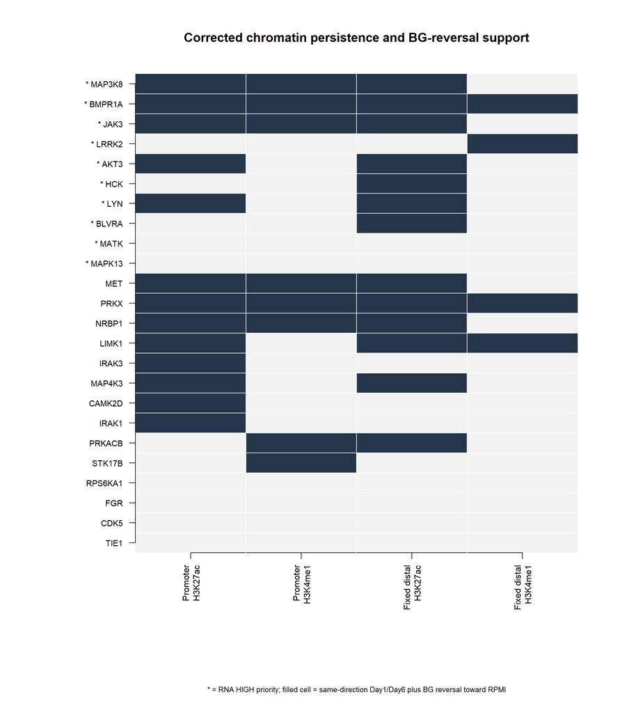

# 10 9. Corrected Day-6 Promoter Audit

A subsequent audit was performed after identifying three RPMI Day-6 replicate-2 BigWig tracks labelled `NotNormalized`:

- GSM2262963 — H3K27ac
- GSM2263007 — H3K4me1
- GSM2263015 — H3K4me3

The corrected local audit uses:

- TSS ±2 kb promoter windows;
- mean BigWig promoter signal;
- log-transformed signal;
- an unpaired limma model;
- statistical testing restricted to kinase genes.

The locally implemented transformation is `log2(signal + 1)`. The exact pseudocount used in the independent analysis was not specified.

The three unnormalized RPMI Day-6 replicate-2 tracks were rescaled locally using normalized-peer global-mean matching. This is an approximation of the correction described during independent review; the exact independent scaling factors were not supplied.

Corrected chromatin audit reproducibility status

| Component | Status | Notes |
| --- | --- | --- |
| Promoter definition | TSS +/- 2 kb |  |
| Signal quantification | Mean BigWig promoter signal |  |
| Transformation | log2(signal + 1) local implementation | Tobias confirmed log transformation but did not specify exact pseudocount |
| Design | Unpaired |  |
| Testing scope | KinHub kinase genes | Tobias confirmed testing was restricted to kinase genes |
| RPMI_d6_rep2 normalization | Three NotNormalized tracks rescaled locally using normalized-peer global-mean matching | Local scaling is an approximation of the correction; exact Tobias scaling factors were not supplied |
| Exact Tobias FDR reproduction | NOT reproduced exactly | Independent corrected results are retained separately from local statistics |
| Downstream candidate decision | JAK3 + EPHB2 | Priority incorporates our RNA results and independent corrected chromatin review |

# 11 10. Local Formal Promoter Results

The local kinase-restricted unpaired limma reconstruction is reported separately from the independent benchmark.

Local formal Day-6 promoter reproduction

| SYMBOL | Mark | Contrast | Log_signal_difference | P_value | FDR | Direction | Local_significant_FDR05 |
| --- | --- | --- | --- | --- | --- | --- | --- |
| JAK3 | H3K27ac | LPS_vs_RPMI | 1.5276880 | 0.0056430 | 0.7011369 | UP | FALSE |
| JAK3 | H3K4me3 | LPS_vs_RPMI | 1.4086020 | 0.0003938 | 0.0652473 | UP | FALSE |
| EPHB2 | H3K27ac | LPS_vs_RPMI | -0.4723786 | 0.3642313 | 0.9989189 | DOWN | FALSE |
| EPHB2 | H3K4me3 | LPS_vs_RPMI | 0.0312193 | 0.9372582 | 0.9950729 | UP | FALSE |
| MET | H3K27ac | LPS_vs_RPMI | 1.3588179 | 0.0039519 | 0.6546917 | UP | FALSE |
| MET | H3K4me3 | LPS_vs_RPMI | 0.9669249 | 0.0148679 | 0.9854138 | UP | FALSE |
| MAP3K8 | H3K27ac | LPS_vs_RPMI | 0.0765531 | 0.8758469 | 0.9989189 | UP | FALSE |
| MAP3K8 | H3K4me3 | LPS_vs_RPMI | 0.1776878 | 0.6541479 | 0.9950729 | UP | FALSE |
| BMPR1A | H3K27ac | LPS_vs_RPMI | -0.0249544 | 0.9448766 | 0.9989189 | DOWN | FALSE |
| BMPR1A | H3K4me3 | LPS_vs_RPMI | -0.1385727 | 0.7267962 | 0.9950729 | DOWN | FALSE |

The local model shows strong nominal promoter signal for JAK3 and MET, but the kinase-family adjusted FDRs do not reproduce the independent corrected values. Most importantly, the independently reported EPHB2 H3K27ac result is not reproduced locally.

Therefore the local analysis is retained as a transparent reproduction audit rather than presented as an exact replication.

# 12 11. Independent Corrected Promoter Benchmark

The following corrected values were reported independently during methodological review and are stored separately from local statistics:

Independent corrected promoter benchmark

| SYMBOL | Mark | Reported_FDR | Reported_contrast | Independent_interpretation |
| --- | --- | --- | --- | --- |
| JAK3 | H3K27ac | 0.0065 | LPS_vs_RPMI | Significant corrected promoter support |
| JAK3 | H3K4me3 | 0.0141 | LPS_vs_RPMI | Significant corrected promoter support |
| EPHB2 | H3K27ac | 0.0300 | Day6 promoter comparison; exact contrast not specified in quoted email | Significant corrected H3K27ac support |
| MET | H3K27ac | 0.0510 | Day6 promoter comparison; exact contrast not specified in quoted email | Not significant after normalization correction |
| MAP3K8 | multiple | NA | Day6 promoter tests | No significant corrected promoter support |
| BMPR1A | multiple | NA | Day6 promoter tests | No significant corrected promoter support |

The independently corrected interpretation is:

- **JAK3:** H3K27ac FDR 0.0065 and H3K4me3 FDR 0.0141;
- **EPHB2:** significant H3K27ac support, reported FDR 0.030;
- **MET:** H3K27ac changed from FDR 0.032 before correction to 0.051 after correction;
- **MAP3K8:** no significant corrected formal promoter support;
- **BMPR1A:** no significant corrected formal promoter support.

For EPHB2 and MET, the quoted correspondence did not explicitly identify the relevant Day-6 contrast in the same sentence as the reported FDR. The benchmark table therefore avoids assigning those values to multiple contrasts.

# 13 12. Current RNA + Chromatin Integration

The final Step-12m integration combines the project’s RNA evidence with the independently corrected promoter review while explicitly recording whether the chromatin result was locally reproduced.

Current integrated candidate status

| SYMBOL | RNA_status | Local_chromatin_reproduction | Independent_corrected_chromatin | Downstream_status | Priority_basis |
| --- | --- | --- | --- | --- | --- |
| JAK3 | Persistent RNA-supported candidate | Strong nominal H3K27ac/H3K4me3 signal; exact Tobias FDRs not reproduced | H3K27ac FDR 0.0065; H3K4me3 FDR 0.0141 | PRIORITIZE | Our RNA evidence + independent corrected promoter chromatin support |
| EPHB2 | Washout-emergent RNA candidate | Independent significant H3K27ac result not reproduced locally | H3K27ac FDR 0.030 | PRIORITIZE | Our washout RNA evidence + independent corrected promoter H3K27ac support |
| MET | RNA-supported candidate | Strong nominal H3K27ac signal; corrected independent FDR is non-significant | H3K27ac FDR 0.051 after correction | RNA_ONLY | RNA evidence; corrected promoter chromatin does not cross FDR 0.05 |
| MAP3K8 | RNA-supported candidate | No local formal promoter support | No significant corrected promoter result | RNA_ONLY | RNA evidence without confirmed formal promoter chromatin support |
| BMPR1A | RNA-supported candidate | No local formal promoter support | No significant corrected promoter result | RNA_ONLY | RNA evidence without confirmed formal promoter chromatin support |

The generated downstream priority is:

**JAK3, EPHB2**

This means that **JAK3 and EPHB2 are prioritized for downstream external validation**.

It does **not** mean that the local chromatin model independently discovered both genes.

# 14 13. Candidate Interpretation

## 14.1 JAK3

JAK3 remains the strongest cross-layer candidate. It has persistent RNA support in the project and independently corrected promoter support for both H3K27ac and H3K4me3.

The local reconstruction also shows strong positive nominal promoter effects, although the exact independent FDR values were not reproduced.

## 14.2 EPHB2

EPHB2 is not part of the original 24 Day-6 kinase-FDR set. It emerged from the broader washout-associated RNA review and gained independently corrected H3K27ac promoter support.

The local promoter reconstruction does not reproduce the reported significant EPHB2 result. This discrepancy is retained explicitly as a reproducibility limitation.

## 14.3 MET

MET remains RNA-supported. Its initially significant H3K27ac result became borderline/non-significant after correction of the RPMI Day-6 normalization issue (reported FDR 0.051), so it is not currently classified as a confirmed RNA + promoter-chromatin hit.

## 14.4 MAP3K8 and BMPR1A

MAP3K8 and BMPR1A retain RNA-level biological interest but do not have significant corrected formal promoter support in the independent review. Their earlier H3K27ac/H3K4me1 directional patterns remain exploratory provenance.

# 15 14. Corrected Final Integration Figure

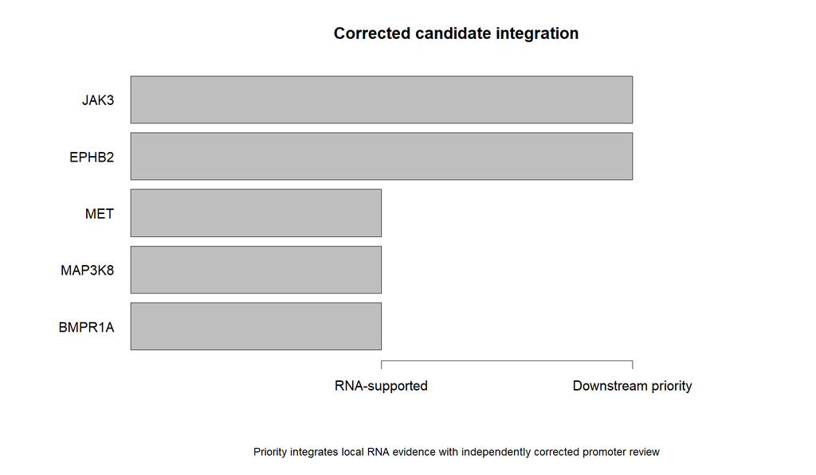

This figure represents the **downstream integration decision**, not an assertion that all chromatin statistics were reproduced locally.

# 16 15. IGV and Locus-Level Interpretation

The previous IGV inspections of MAP3K8, BMPR1A, and JAK3 remain useful as historical qualitative checks, but IGV visualization is not a statistical test and does not override the corrected promoter analysis.

Future locus-level visualization should prioritize **JAK3 and EPHB2**, particularly the Day-6 H3K27ac and H3K4me3 promoter tracks in hg19.

The earlier non-promoter regions remain computationally defined regions rather than experimentally validated enhancers.

# 17 16. Limitations

The main limitations are:

1. **Day-1 RNA sample size:** only two matched pairs were available, limiting FDR power for the acute-response analysis.
2. **β-glucan rescue sample size:** rescue RNA analysis had only two samples and is therefore interpreted primarily as directional/trajectory evidence.
3. **Restimulation interaction:** no memory kinase reached genome-wide FDR significance for the formal history-by-restimulation interaction.
4. **ChIP donor structure:** Day-1 and Day-6 ChIP samples are not longitudinally paired donors.
5. **Chromatin inference:** concordant RNA and chromatin changes do not establish causal epigenetic inheritance.
6. **Legacy regulatory windows:** the Step-07/07b non-promoter regions are computationally selected regions rather than experimentally validated enhancers.
7. **RNA re-analysis:** the RNA workflow is a downstream re-analysis of processed MMSEQ estimates and is not an exact reproduction of the original publication’s differential-expression pipeline.
8. **RPMI Day-6 normalization:** three RPMI_d6_rep2 BigWigs were deposited as `NotNormalized`. The local audit rescales these tracks using normalized-peer genome-wide mean matching; the exact scaling factors used in the independent corrected analysis were not supplied.
9. **Log transformation:** the independent analysis was confirmed to use log-transformed promoter signal, but the exact transformation/pseudocount was not specified. The local implementation uses `log2(signal + 1)`.
10. **Numerical reproduction:** the local kinase-restricted unpaired limma model does not reproduce all independently reported corrected FDR values. In particular, the independently significant EPHB2 H3K27ac result is not reproduced locally.

These limitations are reported explicitly so that independently corrected benchmark results are not presented as locally reproduced statistics.

# 18 17. Conclusion

This re-analysis identifies persistent and washout-associated kinase transcriptional states following LPS exposure and subsequent washout. The original RNA workflow identified 24 Day-6 kinase-family candidates and used acute response, β-glucan rescue, and restimulation behavior to provide additional trajectory context.

The original Step-07/07b/08 chromatin workflow produced **MAP3K8, BMPR1A, and JAK3** as the strongest exploratory RNA/chromatin candidates using directional H3K27ac/H3K4me1 evidence. That ranking is retained as analysis provenance but is no longer treated as the final formal promoter-level result.

A subsequent Day-6 promoter audit incorporated TSS ±2 kb promoter quantification, log-transformed BigWig signal, an unpaired limma design, kinase-restricted statistical testing, and explicit consideration of the three `NotNormalized` RPMI_d6_rep2 tracks.

The local reconstruction and the independently corrected promoter results are deliberately reported separately. The exact independent FDR values were not reproduced locally.

The independently corrected promoter review supports:

- **JAK3:** H3K27ac FDR 0.0065 and H3K4me3 FDR 0.0141;
- **EPHB2:** H3K27ac FDR 0.030;
- **MET:** H3K27ac FDR 0.051 after normalization correction;
- **MAP3K8 and BMPR1A:** no significant corrected formal promoter support.

Accordingly, the current reproducible integration workflow carries **JAK3 and EPHB2 forward for downstream external validation**.

This should be interpreted precisely: **JAK3 + EPHB2 is the downstream integration decision obtained by combining this project’s RNA evidence with the independently corrected promoter review. It is not a claim that the local chromatin limma reconstruction independently identified both genes.**

# 19 18. Reproducibility

The repository contains two related reproducible workflows.

## 19.1 Historical RNA / exploratory chromatin workflow

Run:

```bash
Rscript --vanilla run_all.R
```

This executes Steps 01–08. Its original Step-08 MAP3K8/BMPR1A/JAK3 ranking is retained for provenance and should not be interpreted as the current formal promoter-supported candidate hierarchy.

Historical Steps 01-08 run status

| step | label | status | elapsed_minutes | exit_status |
| --- | --- | --- | --- | --- |
| 01 | Setup and data audit | SUCCESS | 0.186 | 0 |
| 02 | Initial Day-1 LPS response | SUCCESS | 0.255 | 0 |
| 03 | Persistent Day-6 kinase memory | SUCCESS | 0.379 | 0 |
| 04 | Beta-glucan rescue and restimulation | SUCCESS | 0.406 | 0 |
| 05 | Integrated kinase trajectory | SUCCESS | 0.004 | 0 |
| 06 | Final kinase figures | SUCCESS | 0.015 | 0 |
| 07 | Epigenetic persistence | SUCCESS | 0.372 | 0 |
| 07b | Corrected unbiased distal chromatin | SUCCESS | 0.007 | 0 |
| 08 | Final chromatin figures | SUCCESS | 0.014 | 0 |

## 19.2 Corrected Day-6 promoter audit

Run:

```bash
Rscript --vanilla run_corrected_chromatin_audit.R
```

This executes the final corrected audit chain:

```
12a → 12c → 12d → 12e → 12j → 12m
```

where:

- 12a audits the Day-6 chromatin files;
- 12c evaluates global BigWig signal;
- 12d quantifies TSS ±2 kb promoter signal;
- 12e applies the local RPMI_d6_rep2 normalization correction;
- 12j performs the local kinase-restricted unpaired limma reconstruction;
- 12m integrates the local RNA/chromatin audit with the independently corrected promoter benchmark.

Corrected Day-6 chromatin audit status

| step | label | script | status | exit_status |
| --- | --- | --- | --- | --- |
| 12a | Audit Day-6 chromatin files | scripts/12a_audit_day6_chromatin_files.R | SUCCESS | 0 |
| 12c | BigWig global QC | scripts/12c_bigwig_global_qc.R | SUCCESS | 0 |
| 12d | Quantify Day-6 promoters | scripts/12d_quantify_day6_promoters.R | SUCCESS | 0 |
| 12e | Rescale RPMI rep2 promoter signals | scripts/12e_rescale_RPMI_rep2_promoters.R | SUCCESS | 0 |
| 12j | Local Tobias-style kinase limma | scripts/12j_reproduce_Tobias_corrected_limma.R | SUCCESS | 0 |
| 12m | Finalize corrected chromatin audit | scripts/12m_finalize_chromatin_audit.R | SUCCESS | 0 |

A successful corrected audit reports:

```
Successful steps: 6 / 6
Downstream priority: JAK3, EPHB2
```

The final statement is an **integration result**. The independently reported Tobias FDR values remain explicitly separated from locally reproduced statistics.

# 20 19. Key Output Files

## 20.1 RNA analysis

```
results/03_memory_kinases/
  03_memory_kinases_FDR05.csv

results/05_integrated_trajectory/
  05_integrated_kinase_trajectory.csv

figures/06_final_kinase/
  06D_FINAL_integrated_kinase_summary.png
```

## 20.2 Corrected formal chromatin audit

```
results/12_kinase_reevaluation/
  12_run_status.csv
  12a_day6_chromatin_file_manifest.csv
  12c_bigwig_global_qc.csv
  12c_RPMI_rep2_scaling_audit.csv
  12d_day6_sample_manifest.csv
  12d_target_gene_raw_promoter_signal.csv
  12e_RPMI_rep2_scaling_factors.csv
  12e_target_promoter_signal_scaling_audit.csv
  12j_all_kinase_corrected_limma.csv
  12j_target_results.csv
  12m_local_formal_promoter_results.csv
  12m_independent_corrected_benchmark.csv
  12m_FINAL_candidate_status.csv
  12m_reproducibility_summary.csv

figures/12_kinase_reevaluation/
  12m_FINAL_candidate_summary.png
```

## 20.3 Historical exploratory chromatin outputs

```
results/07b_unbiased_distal_chromatin/
  07b_corrected_gene_level_chromatin_summary.csv

results/08_final_chromatin/
  08_TOP_integrated_candidates.csv
  08_TOP_candidate_IGV_loci_hg19.csv
  08_FINAL_professor_table.csv

figures/08_final_chromatin/
  08A_corrected_chromatin_support_all24.png
  08B_HIGH_RNA_Day6_effect_with_chromatin_class.png
  08C_TOP_candidates_chromatin_direction.png
  08D_FINAL_RNA_chromatin_integration.png
```

These Step-07/08 outputs are retained for provenance and exploratory interpretation; they do not determine the current formal promoter-supported downstream priority.

# 21 20. Data Source

Primary SuperSeries: **GSE85246**

ChIP-seq subseries: **GSE85245**

The project analyzes RNA-seq and histone ChIP-seq data from the LPS tolerance / β-glucan reprogramming study by Novakovic and colleagues.

Chromatin analyses use hg19 GEO BigWig tracks for H3K27ac, H3K4me1, and H3K4me3. Large BigWig files are maintained locally and intentionally excluded from Git version control.